# Risk Factor Analysis

## Outcome Variable

**Outcome Variable:** stunted

## Predictor Variables

**Intervention Variable:** nchldlt5

**Adjustment Set:**

- arm
- W_mage
- meducyrs
- feducyrs
- hhwealth_quart
- hfoodsec
- W_mhtcm
- W_nrooms
- W_parity
- impfloor
- impsan
- safeh20
- delta_W_mage
- delta_meducyrs
- delta_feducyrs
- delta_hhwealth_quart
- delta_hfoodsec
- delta_W_mhtcm
- delta_W_nrooms
- delta_W_parity
- delta_impfloor
- delta_impsan
- delta_safeh20

## Stratifying Variables

The analysis was stratified on these variable(s):

- agecat
- studyid
- country

## Data Summary

| agecat | studyid | country | nchldlt5 | stunted | n_cell | n |
| --- | --- | --- | --- | --- | --- | --- |
| Birth | ki1000108-IRC | INDIA | 1 | 0 | 72 | 388 |
| Birth | ki1000108-IRC | INDIA | 1 | 1 | 12 | 388 |
| Birth | ki1000108-IRC | INDIA | 2+ | 0 | 271 | 388 |
| Birth | ki1000108-IRC | INDIA | 2+ | 1 | 33 | 388 |
| Birth | ki1017093c-NIH-Crypto | BANGLADESH | 1 | 0 | 14 | 27 |
| Birth | ki1017093c-NIH-Crypto | BANGLADESH | 1 | 1 | 4 | 27 |
| Birth | ki1017093c-NIH-Crypto | BANGLADESH | 2+ | 0 | 8 | 27 |
| Birth | ki1017093c-NIH-Crypto | BANGLADESH | 2+ | 1 | 1 | 27 |
| Birth | kiGH5241-JiVitA-3 | BANGLADESH | 1 | 0 | 7865 | 19591 |
| Birth | kiGH5241-JiVitA-3 | BANGLADESH | 1 | 1 | 4239 | 19591 |
| Birth | kiGH5241-JiVitA-3 | BANGLADESH | 2+ | 0 | 5393 | 19591 |
| Birth | kiGH5241-JiVitA-3 | BANGLADESH | 2+ | 1 | 2094 | 19591 |
| 6 months | ki1000108-IRC | INDIA | 1 | 0 | 67 | 407 |
| 6 months | ki1000108-IRC | INDIA | 1 | 1 | 22 | 407 |
| 6 months | ki1000108-IRC | INDIA | 2+ | 0 | 240 | 407 |
| 6 months | ki1000108-IRC | INDIA | 2+ | 1 | 78 | 407 |
| 6 months | ki1017093b-PROVIDE | BANGLADESH | 1 | 0 | 357 | 583 |
| 6 months | ki1017093b-PROVIDE | BANGLADESH | 1 | 1 | 69 | 583 |
| 6 months | ki1017093b-PROVIDE | BANGLADESH | 2+ | 0 | 132 | 583 |
| 6 months | ki1017093b-PROVIDE | BANGLADESH | 2+ | 1 | 25 | 583 |
| 6 months | ki1017093c-NIH-Crypto | BANGLADESH | 1 | 0 | 400 | 715 |
| 6 months | ki1017093c-NIH-Crypto | BANGLADESH | 1 | 1 | 107 | 715 |
| 6 months | ki1017093c-NIH-Crypto | BANGLADESH | 2+ | 0 | 165 | 715 |
| 6 months | ki1017093c-NIH-Crypto | BANGLADESH | 2+ | 1 | 43 | 715 |
| 6 months | ki1066203-TanzaniaChild2 | TANZANIA, UNITED REPUBLIC OF | 1 | 0 | 1267 | 2020 |
| 6 months | ki1066203-TanzaniaChild2 | TANZANIA, UNITED REPUBLIC OF | 1 | 1 | 124 | 2020 |
| 6 months | ki1066203-TanzaniaChild2 | TANZANIA, UNITED REPUBLIC OF | 2+ | 0 | 558 | 2020 |
| 6 months | ki1066203-TanzaniaChild2 | TANZANIA, UNITED REPUBLIC OF | 2+ | 1 | 71 | 2020 |
| 6 months | ki1148112-LCNI-5 | MALAWI | 1 | 0 | 263 | 811 |
| 6 months | ki1148112-LCNI-5 | MALAWI | 1 | 1 | 127 | 811 |
| 6 months | ki1148112-LCNI-5 | MALAWI | 2+ | 0 | 253 | 811 |
| 6 months | ki1148112-LCNI-5 | MALAWI | 2+ | 1 | 168 | 811 |
| 6 months | kiGH5241-JiVitA-3 | BANGLADESH | 1 | 0 | 8093 | 16800 |
| 6 months | kiGH5241-JiVitA-3 | BANGLADESH | 1 | 1 | 2794 | 16800 |
| 6 months | kiGH5241-JiVitA-3 | BANGLADESH | 2+ | 0 | 4484 | 16800 |
| 6 months | kiGH5241-JiVitA-3 | BANGLADESH | 2+ | 1 | 1429 | 16800 |
| 24 months | ki1000108-IRC | INDIA | 1 | 0 | 58 | 409 |
| 24 months | ki1000108-IRC | INDIA | 1 | 1 | 31 | 409 |
| 24 months | ki1000108-IRC | INDIA | 2+ | 0 | 181 | 409 |
| 24 months | ki1000108-IRC | INDIA | 2+ | 1 | 139 | 409 |
| 24 months | ki1017093b-PROVIDE | BANGLADESH | 1 | 0 | 298 | 577 |
| 24 months | ki1017093b-PROVIDE | BANGLADESH | 1 | 1 | 125 | 577 |
| 24 months | ki1017093b-PROVIDE | BANGLADESH | 2+ | 0 | 89 | 577 |
| 24 months | ki1017093b-PROVIDE | BANGLADESH | 2+ | 1 | 65 | 577 |
| 24 months | ki1017093c-NIH-Crypto | BANGLADESH | 1 | 0 | 276 | 514 |
| 24 months | ki1017093c-NIH-Crypto | BANGLADESH | 1 | 1 | 81 | 514 |
| 24 months | ki1017093c-NIH-Crypto | BANGLADESH | 2+ | 0 | 106 | 514 |
| 24 months | ki1017093c-NIH-Crypto | BANGLADESH | 2+ | 1 | 51 | 514 |
| 24 months | ki1066203-TanzaniaChild2 | TANZANIA, UNITED REPUBLIC OF | 1 | 0 | 4 | 6 |
| 24 months | ki1066203-TanzaniaChild2 | TANZANIA, UNITED REPUBLIC OF | 1 | 1 | 1 | 6 |
| 24 months | ki1066203-TanzaniaChild2 | TANZANIA, UNITED REPUBLIC OF | 2+ | 0 | 1 | 6 |
| 24 months | ki1066203-TanzaniaChild2 | TANZANIA, UNITED REPUBLIC OF | 2+ | 1 | 0 | 6 |
| 24 months | ki1148112-LCNI-5 | MALAWI | 1 | 0 | 163 | 571 |
| 24 months | ki1148112-LCNI-5 | MALAWI | 1 | 1 | 120 | 571 |
| 24 months | ki1148112-LCNI-5 | MALAWI | 2+ | 0 | 158 | 571 |
| 24 months | ki1148112-LCNI-5 | MALAWI | 2+ | 1 | 130 | 571 |
| 24 months | kiGH5241-JiVitA-3 | BANGLADESH | 1 | 0 | 2892 | 8622 |
| 24 months | kiGH5241-JiVitA-3 | BANGLADESH | 1 | 1 | 2562 | 8622 |
| 24 months | kiGH5241-JiVitA-3 | BANGLADESH | 2+ | 0 | 1499 | 8622 |
| 24 months | kiGH5241-JiVitA-3 | BANGLADESH | 2+ | 1 | 1669 | 8622 |

The following strata were considered:

- agecat: 24 months, studyid: ki1000108-IRC, country: INDIA
- agecat: 24 months, studyid: ki1017093b-PROVIDE, country: BANGLADESH
- agecat: 24 months, studyid: ki1017093c-NIH-Crypto, country: BANGLADESH
- agecat: 24 months, studyid: ki1066203-TanzaniaChild2, country: TANZANIA, UNITED REPUBLIC OF
- agecat: 24 months, studyid: ki1148112-LCNI-5, country: MALAWI
- agecat: 24 months, studyid: kiGH5241-JiVitA-3, country: BANGLADESH
- agecat: 6 months, studyid: ki1000108-IRC, country: INDIA
- agecat: 6 months, studyid: ki1017093b-PROVIDE, country: BANGLADESH
- agecat: 6 months, studyid: ki1017093c-NIH-Crypto, country: BANGLADESH
- agecat: 6 months, studyid: ki1066203-TanzaniaChild2, country: TANZANIA, UNITED REPUBLIC OF
- agecat: 6 months, studyid: ki1148112-LCNI-5, country: MALAWI
- agecat: 6 months, studyid: kiGH5241-JiVitA-3, country: BANGLADESH
- agecat: Birth, studyid: ki1000108-IRC, country: INDIA
- agecat: Birth, studyid: ki1017093c-NIH-Crypto, country: BANGLADESH
- agecat: Birth, studyid: kiGH5241-JiVitA-3, country: BANGLADESH

### Dropped Strata

Some strata were dropped due to rare outcomes:

- agecat: Birth, studyid: ki1017093c-NIH-Crypto, country: BANGLADESH
- agecat: 24 months, studyid: ki1066203-TanzaniaChild2, country: TANZANIA, UNITED REPUBLIC OF

## Methods Detail

We’re interested in the causal parameters $E[Y_a]$ for all values of $a \in \mathcal{A}$. These parameters represent the mean outcome if, possibly contrary to fact, we intervened to set all units to have $A=a$. Under the randomization and positivity assumptions, these are identified by the statistical parameters $\psi_a=E_W[E_{Y|A,W}(Y|A=a,W)]$. In addition, we’re interested in the mean of $Y$, $E[Y]$ under no intervention (the observed mean). We will estimate these parameters by using SuperLearner to fit the relevant likelihood factors – $E_{Y|A,W}(Y|A=a,W)$ and $p(A=a|W)$, and then updating our likelihood fit using a joint TMLE.

For unadjusted analyses ($W=\{\}$), initial likelihoods were estimated using Lrnr_glm to estimate the simple $E(Y|A)$ and Lrnr_mean to estimate $p(A)$. For adjusted analyses, a small library containing Lrnr_glmnet, Lrnr_xgboost, and Lrnr_mean was used.

Having estimated these parameters, we will then use the delta method to estimate relative risks and attributable risks relative to a prespecified baseline level of $A$.

# Results Detail

## Results Plots

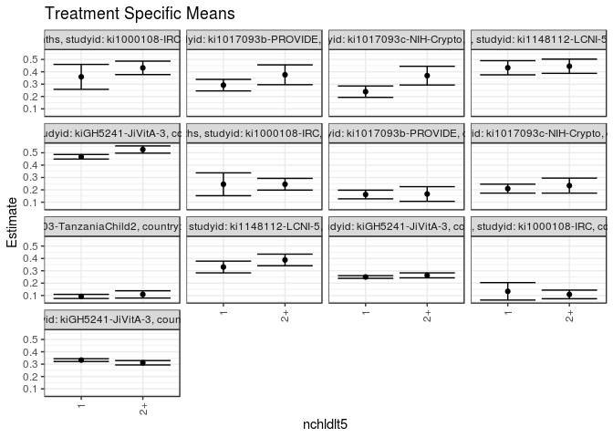

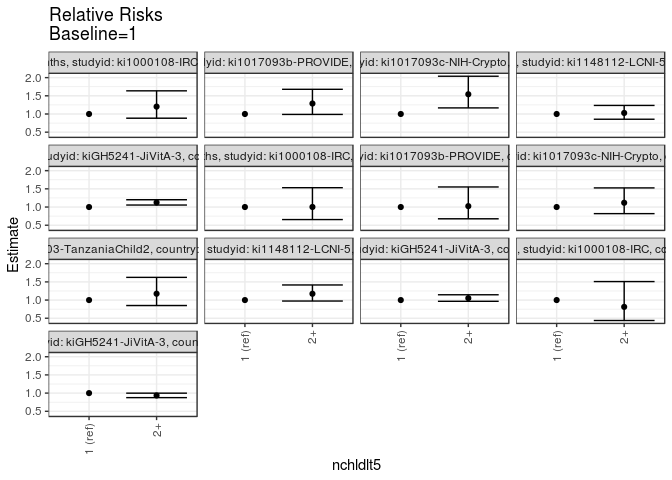

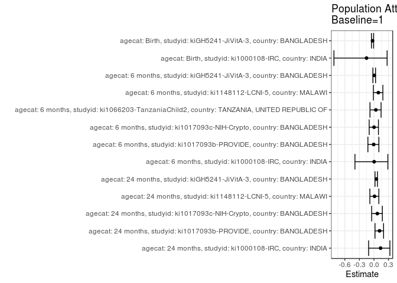

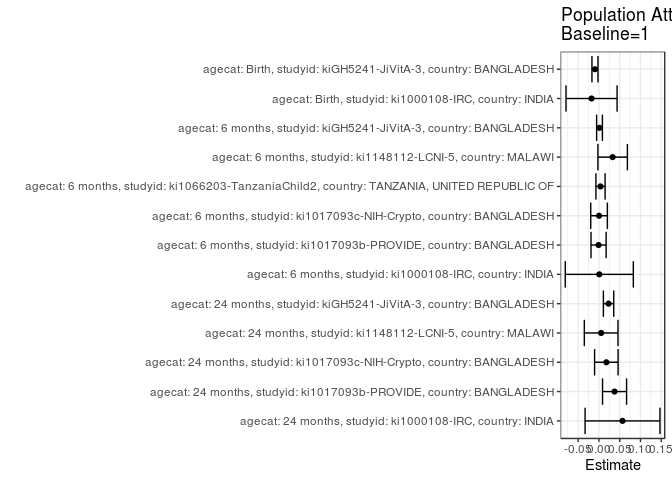

## Results Table

### Parameter: TSM

| agecat | studyid | country | intervention_level | baseline_level | estimate | ci_lower | ci_upper |
| --- | --- | --- | --- | --- | --- | --- | --- |
| Birth | ki1000108-IRC | INDIA | 1 | NA | 0.1337761 | 0.0631019 | 0.2044503 |
| Birth | ki1000108-IRC | INDIA | 2+ | NA | 0.1087019 | 0.0737491 | 0.1436547 |
| Birth | kiGH5241-JiVitA-3 | BANGLADESH | 1 | NA | 0.3328352 | 0.3216325 | 0.3440379 |
| Birth | kiGH5241-JiVitA-3 | BANGLADESH | 2+ | NA | 0.3111264 | 0.2932414 | 0.3290114 |
| 6 months | ki1000108-IRC | INDIA | 1 | NA | 0.2448336 | 0.1523671 | 0.3373000 |
| 6 months | ki1000108-IRC | INDIA | 2+ | NA | 0.2452094 | 0.1977301 | 0.2926886 |
| 6 months | ki1017093b-PROVIDE | BANGLADESH | 1 | NA | 0.1621438 | 0.1270530 | 0.1972346 |
| 6 months | ki1017093b-PROVIDE | BANGLADESH | 2+ | NA | 0.1661300 | 0.1067986 | 0.2254615 |
| 6 months | ki1017093c-NIH-Crypto | BANGLADESH | 1 | NA | 0.2095233 | 0.1734003 | 0.2456463 |
| 6 months | ki1017093c-NIH-Crypto | BANGLADESH | 2+ | NA | 0.2341225 | 0.1733608 | 0.2948841 |
| 6 months | ki1066203-TanzaniaChild2 | TANZANIA, UNITED REPUBLIC OF | 1 | NA | 0.0927557 | 0.0760459 | 0.1094656 |
| 6 months | ki1066203-TanzaniaChild2 | TANZANIA, UNITED REPUBLIC OF | 2+ | NA | 0.1089442 | 0.0796105 | 0.1382780 |
| 6 months | ki1148112-LCNI-5 | MALAWI | 1 | NA | 0.3307681 | 0.2833162 | 0.3782201 |
| 6 months | ki1148112-LCNI-5 | MALAWI | 2+ | NA | 0.3881116 | 0.3412230 | 0.4350002 |
| 6 months | kiGH5241-JiVitA-3 | BANGLADESH | 1 | NA | 0.2500050 | 0.2391976 | 0.2608124 |
| 6 months | kiGH5241-JiVitA-3 | BANGLADESH | 2+ | NA | 0.2631319 | 0.2429238 | 0.2833400 |
| 24 months | ki1000108-IRC | INDIA | 1 | NA | 0.3588896 | 0.2579511 | 0.4598282 |
| 24 months | ki1000108-IRC | INDIA | 2+ | NA | 0.4317077 | 0.3772901 | 0.4861252 |
| 24 months | ki1017093b-PROVIDE | BANGLADESH | 1 | NA | 0.2917004 | 0.2450843 | 0.3383164 |
| 24 months | ki1017093b-PROVIDE | BANGLADESH | 2+ | NA | 0.3756079 | 0.2951886 | 0.4560273 |
| 24 months | ki1017093c-NIH-Crypto | BANGLADESH | 1 | NA | 0.2390252 | 0.1930117 | 0.2850386 |
| 24 months | ki1017093c-NIH-Crypto | BANGLADESH | 2+ | NA | 0.3687113 | 0.2928478 | 0.4445749 |
| 24 months | ki1148112-LCNI-5 | MALAWI | 1 | NA | 0.4325063 | 0.3753301 | 0.4896825 |
| 24 months | ki1148112-LCNI-5 | MALAWI | 2+ | NA | 0.4448566 | 0.3873487 | 0.5023646 |
| 24 months | kiGH5241-JiVitA-3 | BANGLADESH | 1 | NA | 0.4675876 | 0.4490713 | 0.4861039 |
| 24 months | kiGH5241-JiVitA-3 | BANGLADESH | 2+ | NA | 0.5261714 | 0.4970178 | 0.5553250 |

### Parameter: E(Y)

| agecat | studyid | country | intervention_level | baseline_level | estimate | ci_lower | ci_upper |
| --- | --- | --- | --- | --- | --- | --- | --- |
| Birth | ki1000108-IRC | INDIA | NA | NA | 0.1159794 | 0.0840777 | 0.1478811 |
| Birth | kiGH5241-JiVitA-3 | BANGLADESH | NA | NA | 0.3232607 | 0.3156042 | 0.3309171 |
| 6 months | ki1000108-IRC | INDIA | NA | NA | 0.2457002 | 0.2038248 | 0.2875757 |
| 6 months | ki1017093b-PROVIDE | BANGLADESH | NA | NA | 0.1612350 | 0.1313580 | 0.1911120 |
| 6 months | ki1017093c-NIH-Crypto | BANGLADESH | NA | NA | 0.2097902 | 0.1799252 | 0.2396552 |
| 6 months | ki1066203-TanzaniaChild2 | TANZANIA, UNITED REPUBLIC OF | NA | NA | 0.0965347 | 0.0836528 | 0.1094165 |
| 6 months | ki1148112-LCNI-5 | MALAWI | NA | NA | 0.3637485 | 0.3306185 | 0.3968784 |
| 6 months | kiGH5241-JiVitA-3 | BANGLADESH | NA | NA | 0.2513690 | 0.2432434 | 0.2594947 |
| 24 months | ki1000108-IRC | INDIA | NA | NA | 0.4156479 | 0.3678270 | 0.4634689 |
| 24 months | ki1017093b-PROVIDE | BANGLADESH | NA | NA | 0.3292894 | 0.2909105 | 0.3676684 |
| 24 months | ki1017093c-NIH-Crypto | BANGLADESH | NA | NA | 0.2568093 | 0.2190047 | 0.2946140 |
| 24 months | ki1148112-LCNI-5 | MALAWI | NA | NA | 0.4378284 | 0.3971000 | 0.4785567 |
| 24 months | kiGH5241-JiVitA-3 | BANGLADESH | NA | NA | 0.4907214 | 0.4775947 | 0.5038481 |

### Parameter: RR

| agecat | studyid | country | intervention_level | baseline_level | estimate | ci_lower | ci_upper |
| --- | --- | --- | --- | --- | --- | --- | --- |
| Birth | ki1000108-IRC | INDIA | 1 | 1 | 1.0000000 | 1.0000000 | 1.0000000 |
| Birth | ki1000108-IRC | INDIA | 2+ | 1 | 0.8125657 | 0.4377327 | 1.5083702 |
| Birth | kiGH5241-JiVitA-3 | BANGLADESH | 1 | 1 | 1.0000000 | 1.0000000 | 1.0000000 |
| Birth | kiGH5241-JiVitA-3 | BANGLADESH | 2+ | 1 | 0.9347761 | 0.8755131 | 0.9980505 |
| 6 months | ki1000108-IRC | INDIA | 1 | 1 | 1.0000000 | 1.0000000 | 1.0000000 |
| 6 months | ki1000108-IRC | INDIA | 2+ | 1 | 1.0015349 | 0.6547472 | 1.5319992 |
| 6 months | ki1017093b-PROVIDE | BANGLADESH | 1 | 1 | 1.0000000 | 1.0000000 | 1.0000000 |
| 6 months | ki1017093b-PROVIDE | BANGLADESH | 2+ | 1 | 1.0245846 | 0.6764899 | 1.5517950 |
| 6 months | ki1017093c-NIH-Crypto | BANGLADESH | 1 | 1 | 1.0000000 | 1.0000000 | 1.0000000 |
| 6 months | ki1017093c-NIH-Crypto | BANGLADESH | 2+ | 1 | 1.1174054 | 0.8184585 | 1.5255446 |
| 6 months | ki1066203-TanzaniaChild2 | TANZANIA, UNITED REPUBLIC OF | 1 | 1 | 1.0000000 | 1.0000000 | 1.0000000 |
| 6 months | ki1066203-TanzaniaChild2 | TANZANIA, UNITED REPUBLIC OF | 2+ | 1 | 1.1745286 | 0.8494550 | 1.6240030 |
| 6 months | ki1148112-LCNI-5 | MALAWI | 1 | 1 | 1.0000000 | 1.0000000 | 1.0000000 |
| 6 months | ki1148112-LCNI-5 | MALAWI | 2+ | 1 | 1.1733644 | 0.9732110 | 1.4146820 |
| 6 months | kiGH5241-JiVitA-3 | BANGLADESH | 1 | 1 | 1.0000000 | 1.0000000 | 1.0000000 |
| 6 months | kiGH5241-JiVitA-3 | BANGLADESH | 2+ | 1 | 1.0525067 | 0.9665321 | 1.1461289 |
| 24 months | ki1000108-IRC | INDIA | 1 | 1 | 1.0000000 | 1.0000000 | 1.0000000 |
| 24 months | ki1000108-IRC | INDIA | 2+ | 1 | 1.2028982 | 0.8842792 | 1.6363203 |
| 24 months | ki1017093b-PROVIDE | BANGLADESH | 1 | 1 | 1.0000000 | 1.0000000 | 1.0000000 |
| 24 months | ki1017093b-PROVIDE | BANGLADESH | 2+ | 1 | 1.2876500 | 0.9873027 | 1.6793658 |
| 24 months | ki1017093c-NIH-Crypto | BANGLADESH | 1 | 1 | 1.0000000 | 1.0000000 | 1.0000000 |
| 24 months | ki1017093c-NIH-Crypto | BANGLADESH | 2+ | 1 | 1.5425627 | 1.1672435 | 2.0385634 |
| 24 months | ki1148112-LCNI-5 | MALAWI | 1 | 1 | 1.0000000 | 1.0000000 | 1.0000000 |
| 24 months | ki1148112-LCNI-5 | MALAWI | 2+ | 1 | 1.0285553 | 0.8564036 | 1.2353123 |
| 24 months | kiGH5241-JiVitA-3 | BANGLADESH | 1 | 1 | 1.0000000 | 1.0000000 | 1.0000000 |
| 24 months | kiGH5241-JiVitA-3 | BANGLADESH | 2+ | 1 | 1.1252895 | 1.0545627 | 1.2007596 |

### Parameter: PAR

| agecat | studyid | country | intervention_level | baseline_level | estimate | ci_lower | ci_upper |
| --- | --- | --- | --- | --- | --- | --- | --- |
| Birth | ki1000108-IRC | INDIA | 1 | NA | -0.0177967 | -0.0792682 | 0.0436747 |
| Birth | kiGH5241-JiVitA-3 | BANGLADESH | 1 | NA | -0.0095745 | -0.0168361 | -0.0023129 |
| 6 months | ki1000108-IRC | INDIA | 1 | NA | 0.0008667 | -0.0810318 | 0.0827651 |
| 6 months | ki1017093b-PROVIDE | BANGLADESH | 1 | NA | -0.0009088 | -0.0191089 | 0.0172913 |
| 6 months | ki1017093c-NIH-Crypto | BANGLADESH | 1 | NA | 0.0002669 | -0.0197500 | 0.0202838 |
| 6 months | ki1066203-TanzaniaChild2 | TANZANIA, UNITED REPUBLIC OF | 1 | NA | 0.0037789 | -0.0072420 | 0.0147999 |
| 6 months | ki1148112-LCNI-5 | MALAWI | 1 | NA | 0.0329803 | -0.0024986 | 0.0684592 |
| 6 months | kiGH5241-JiVitA-3 | BANGLADESH | 1 | NA | 0.0013641 | -0.0056011 | 0.0083293 |
| 24 months | ki1000108-IRC | INDIA | 1 | NA | 0.0567583 | -0.0333388 | 0.1468554 |
| 24 months | ki1017093b-PROVIDE | BANGLADESH | 1 | NA | 0.0375891 | 0.0086532 | 0.0665249 |
| 24 months | ki1017093c-NIH-Crypto | BANGLADESH | 1 | NA | 0.0177842 | -0.0104659 | 0.0460343 |
| 24 months | ki1148112-LCNI-5 | MALAWI | 1 | NA | 0.0053221 | -0.0351916 | 0.0458357 |
| 24 months | kiGH5241-JiVitA-3 | BANGLADESH | 1 | NA | 0.0231338 | 0.0106991 | 0.0355685 |

### Parameter: PAF

| agecat | studyid | country | intervention_level | baseline_level | estimate | ci_lower | ci_upper |
| --- | --- | --- | --- | --- | --- | --- | --- |
| Birth | ki1000108-IRC | INDIA | 1 | NA | -0.1534475 | -0.8255315 | 0.2712034 |
| Birth | kiGH5241-JiVitA-3 | BANGLADESH | 1 | NA | -0.0296186 | -0.0522488 | -0.0074750 |
| 6 months | ki1000108-IRC | INDIA | 1 | NA | 0.0035273 | -0.3923341 | 0.2868394 |
| 6 months | ki1017093b-PROVIDE | BANGLADESH | 1 | NA | -0.0056366 | -0.1250923 | 0.1011360 |
| 6 months | ki1017093c-NIH-Crypto | BANGLADESH | 1 | NA | 0.0012724 | -0.0988501 | 0.0922721 |
| 6 months | ki1066203-TanzaniaChild2 | TANZANIA, UNITED REPUBLIC OF | 1 | NA | 0.0391459 | -0.0820441 | 0.1467625 |
| 6 months | ki1148112-LCNI-5 | MALAWI | 1 | NA | 0.0906679 | -0.0122721 | 0.1831397 |
| 6 months | kiGH5241-JiVitA-3 | BANGLADESH | 1 | NA | 0.0054266 | -0.0226762 | 0.0327571 |
| 24 months | ki1000108-IRC | INDIA | 1 | NA | 0.1365538 | -0.1100713 | 0.3283860 |
| 24 months | ki1017093b-PROVIDE | BANGLADESH | 1 | NA | 0.1141521 | 0.0215677 | 0.1979757 |
| 24 months | ki1017093c-NIH-Crypto | BANGLADESH | 1 | NA | 0.0692505 | -0.0474588 | 0.1729558 |
| 24 months | ki1148112-LCNI-5 | MALAWI | 1 | NA | 0.0121556 | -0.0848459 | 0.1004837 |
| 24 months | kiGH5241-JiVitA-3 | BANGLADESH | 1 | NA | 0.0471425 | 0.0213677 | 0.0722384 |